# Molecular Dynamics Workflow

Veronica Gosnell, M.S.

# Overview

This vignette presents a reproducible workflow for performing, processing, analyzing, and visualizing Molecular Dynamics (`MD`) simulations of vaccine–receptor complexes using `GROMACS`, `R`, `APBS`, and `PyMOL`.

The workflow spans the complete simulation pipeline, beginning with SLURM-based high-performance computing (`HPC`) simulation setup and continuing through **trajectory processing**, **structural analysis**, **representative structure extraction**, and **electrostatic surface visualization**.

The workflow includes:

- `SLURM`-based simulation execution
- Energy minimization and equilibration
- Multi-stage production `MD` simulations
- Trajectory combination and processing
- Root Mean Square Deviation (`RMSD`) analysis
- Root Mean Square Fluctuation (`RMSF`) analysis
- Radius of Gyration (`Rg`) analysis
- Hydrogen bond analysis
- Representative structure extraction
- Comparison of docking and `MD`-refined structures
- Electrostatic surface representation and visualization

This workflow is designed to support reproducible analysis of protein–protein interaction systems and can be adapted for additional molecular simulation studies.

# Setup GROMACS Environment

```python
conda create -n gromacs2025 python=3.11 cmake make gcc gxx fftw openmpi -c conda-forge

conda activate gromacs2025
```

# Running MD Simulation Jobs on SLURM

The simulation stage of this workflow is designed to run on a `SLURM`-based high-performance computing (`HPC`) system. The simulation scripts are provided in the `scripts/simulation/` directory and should be submitted using `sbatch`.

The workflow includes three main simulation stages:

1. Minimization and equilibration
2. Production run 1
3. Production run 2 / continuation run

## Submit Minimization and Equilibration

The minimization and equilibration script performs energy minimization followed by NVT and NPT equilibration.

From the repository root, submit the job using:

```bash
sbatch scripts/simulation/minimization_equilibration.sh
```

After submission, `SLURM` will return a job ID:

```
Submitted batch job 123456
```

## Submit Production Run 1

After **minimization** and **equilibration** complete successfully, submit the first production run:

```bash
sbatch scripts/simulation/production_run1.sh
```

This script starts the first production `MD` simulation using the equilibrated system files.

## Submit Production Run 2

After production run 1 completes successfully, submit the continuation run:

```bash
sbatch scripts/simulation/production_run2.sh
```

This script continues the simulation from the checkpoint or output files generated by production run 1.

## Recommended: Submit Jobs with Dependencies

To avoid manually waiting for each job to finish, `SLURM` job dependencies can be used so that each step begins only after the previous step completes successfully.

```bash
job1=$(sbatch scripts/simulation/minimization_equilibration.sh | awk '{print $4}')

job2=$(sbatch --dependency=afterok:$job1 scripts/simulation/production_run1.sh | awk '{print $4}')

job3=$(sbatch --dependency=afterok:$job2 scripts/simulation/production_run2.sh | awk '{print $4}')
```

This ensures:

- Production run 1 starts only if minimization/equilibration completes successfully
- Production run 2 starts only if production run 1 completes successfully

## Full Pipeline Submission

A full `SLURM` submission script is also provided at the repository root:

```bash
bash run_all.sh
```

This script submits the simulation and post-processing workflow using `SLURM` job dependencies.

## Notes

`SLURM` options such as partition, wall time, number of nodes, number of tasks, and memory requirements should be adjusted according to the target `HPC` system.

The simulation scripts are intended for `HPC` execution and are not expected to run directly on a local laptop unless `GROMACS` and the required input files are configured locally.

# Run the Full Analysis

The complete local analysis workflow can be run from the repository root using:

```r
source("scripts/analysis/run_analysis.R")
```

# Trajectory Combination and Processing

Multiple production trajectory segments were combined and processed prior to downstream analysis. This step generates a continuous trajectory and applies periodic boundary condition correction and centering for visualization and analysis.

From the repository root:

```bash
bash scripts/post_processing/combine_trajectories.sh
```

## Workflow Summary

The script performs the following steps:

1. Generates an index file using the input structure.
2. Combines production trajectory segments into a single trajectory.
3. Applies periodic boundary condition correction.
4. Centers the system for downstream analysis.
5. Generates processed trajectory files for full-system and protein-focused analyses.

## GROMACS Commands

Create an index file:

```bash
gmx make_ndx -f step3_input.gro -o index.ndx
```

Combine trajectory segments:

```bash
gmx trjcat -f step5_production.xtc step5_production.part*.xtc -o step-all.xtc
```

Apply PBC correction and centering:

```bash
gmx trjconv -f step-all.xtc -s step5_production.tpr -n index.ndx \
  -pbc mol -ur compact -center -o out.xtc
```

```bash
gmx trjconv -f step-all.xtc -s step5_production.tpr -n index.ndx \
  -pbc mol -ur compact -center -o out_prot.xtc
```

## Output Files

- `index.ndx` — GROMACS index file
- `step-all.xtc` — combined production trajectory
- `out.xtc` — PBC-corrected and centered trajectory
- `out_prot.xtc` — protein-centered trajectory for downstream analysis

# RMSD Analysis

Root Mean Square Deviation `(RMSD)` was used to evaluate the overall structural stability of the vaccine-receptor complex over time. RMSD measures the average positional deviation of selected atoms relative to a reference structure.

Lower and plateauing `RMSD` values generally suggest that the system has reached structural stability, while large or continuously increasing `RMSD` values may indicate conformational instability or major structural rearrangement.

## GROMACS Command

```bash
gmx rms -f out.xtc -s step5_production.tpr -n index.ndx -o rmsd.xvg -tu ns
```

## Output Plot

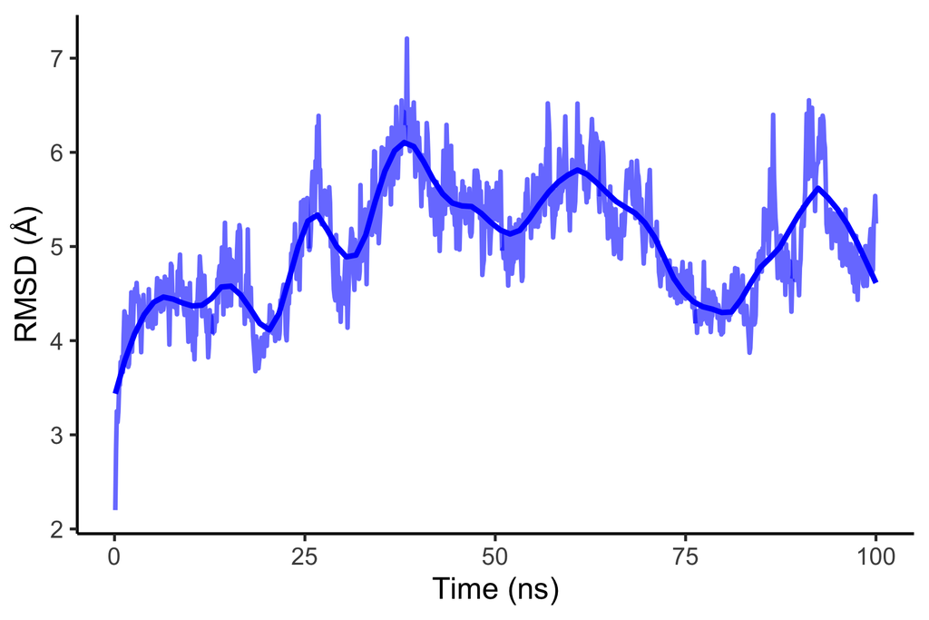

*Figure: RMSD profile showing structural deviation of the vaccine-receptor complex over time.*

# Component-Specific Analysis: Separating Receptor and Vaccine Groups

For `RMSF` and radius of gyration `(Rg)` analyses, the receptor and vaccine components were *separated* into distinct index groups. This is important because the receptor and vaccine may differ substantially in size, residue numbering, flexibility, and structural compactness.

Analyzing the full complex alone can obscure component-specific behavior. For example, high flexibility in the *vaccine* construct may be masked by the larger *receptor*, while receptor compactness may dominate the radius of gyration profile of the full complex. Separating the components allows `RMSF` and `Rg` to be interpreted independently for each molecular partner.

Residue ranges were first confirmed in `PyMOL` by inspecting the receptor and vaccine sequences. These residue ranges were then used to create separate `GROMACS` index groups.

## Create Receptor and Vaccine Index Groups

```bash
gmx make_ndx -f step5_production.tpr -n index.ndx -o index_separated.ndx
```

Within the interactive `GROMACS` prompt, enter `l` to list available residue and atom groups, then define the *receptor* and *vaccine* groups by residue index:

[output not shown]

The residue ranges shown here are system-specific and should be adjusted according to the *receptor* and *vaccine* residue numbering in **each complex**.

# RMSF Analysis

Root Mean Square Fluctuation `(RMSF)` was used to evaluate residue-level flexibility throughout the MD simulation. `RMSF` identifies regions of the protein or vaccine construct that exhibit **increased** atomic displacement over time.

Higher `RMSF` values typically correspond to flexible loops, termini, or exposed regions, while lower `RMSF` values suggest more stable or structurally constrained residues.

## GROMACS Commands

Calculate `RMSF` for the vaccine component:

```bash
echo "Vaccine" | gmx rmsf \
  -s step5_production.tpr \
  -f step-all.xtc \
  -o rmsf_vaccine.xvg \
  -res \
  -n index_separated.ndx
```

Calculate `RMSF` for the receptor component:

```bash
echo "Receptor" | gmx rmsf \
  -s step5_production.tpr \
  -f step-all.xtc \
  -o rmsf_receptor.xvg \
  -res \
  -n index_separated.ndx
```

## Output Plot

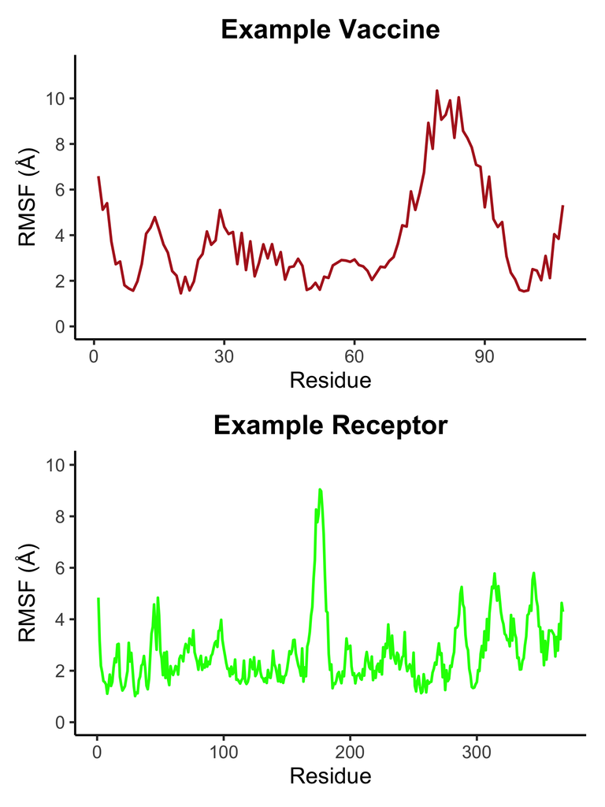

*Figure: Per-residue RMSF profile showing local flexibility across the separated components of the vaccine-receptor complex in order to analyze them individually.*

# Radius of Gyration Analysis

Radius of Gyration `(Rg)` was used to assess the compactness of the vaccine-receptor complex over time. `Rg` measures the distribution of atoms around the center of mass of the molecule.

Stable `Rg` values suggest that the system maintains compactness during simulation, while increasing `Rg` values may indicate unfolding, expansion, or loosening of the complex.

## GROMACS Commands

Calculate radius of gyration for the vaccine component:

```bash
echo "Vaccine" | gmx gyrate \
  -f step-all.xtc \
  -s step5_production.tpr \
  -n index_separated.ndx \
  -o rg_vaccine.xvg
```

Calculate radius of gyration for the receptor component:

```bash
echo "Receptor" | gmx gyrate \
  -f step-all.xtc \
  -s step5_production.tpr \
  -n index_separated.ndx \
  -o rg_receptor.xvg
```

## Output Plot

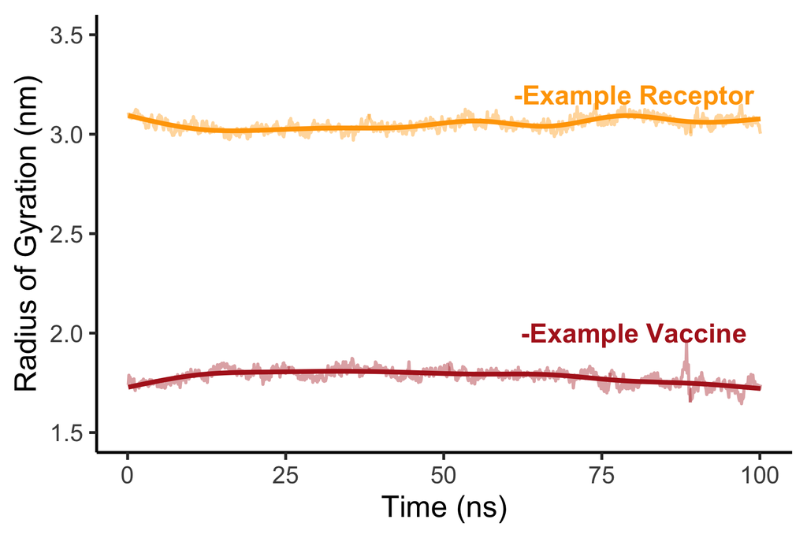

*Figure: Radius of gyration profile showing changes in structural compactness of the separated vaccine-receptor complex components over time.*

# Hydrogen Bond Analysis

Hydrogen bond analysis was used to evaluate intramolecular interaction stability between the vaccine and receptor components during the MD simulation. The number of hydrogen bonds provides insight into structural integrity and interaction persistence over time.

A relatively stable hydrogen bond profile may indicate sustained internal interactions, while large fluctuations may reflect conformational rearrangement or transient interaction changes.

## GROMACS Command

```bash
gmx hbond -f out.xtc -s step5_production.tpr -n index.ndx -num hbnum.xvg -g hbond.log -hbn hbond.ndx -hbm hbmap.xpm
```

## Output Plot

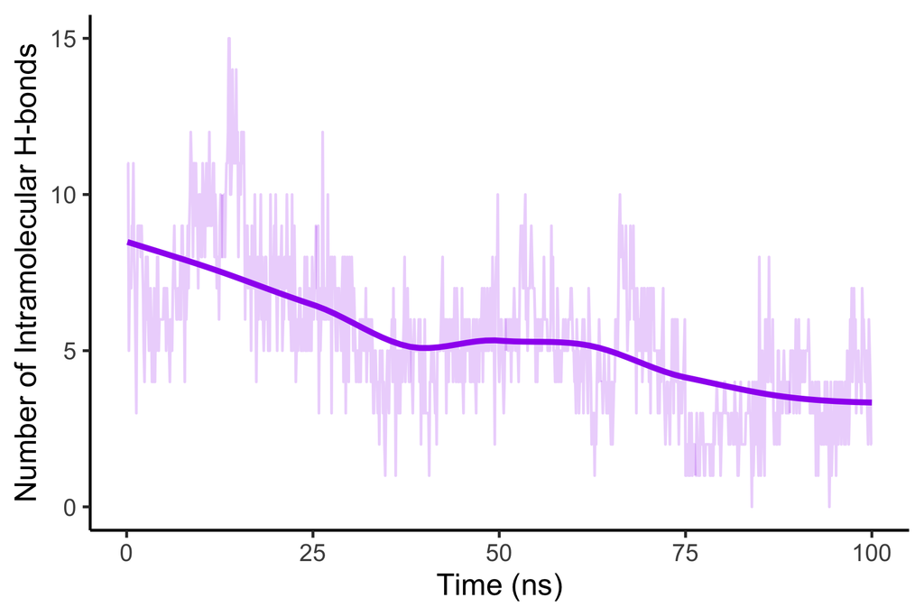

*Figure: Hydrogen bond profile showing changes in intramolecular hydrogen bonding between the vaccine and receptor throughout the simulation.*

# Representative Structure Extraction

Representative structures were extracted from the processed MD trajectory using `GROMACS`. This step fits the trajectory, performs clustering, and extracts a central representative structure for downstream visualization and electrostatic surface analysis.

From the repository root:

```bash
bash scripts/post_processing/extract_average_frame.sh
```

## Workflow Summary

The script performs the following steps:

1. Fits the trajectory using rotational and translational alignment.
2. Clusters the fitted trajectory using the `GROMOS` method.
3. Extracts a representative central structure from the clustered trajectory.

## GROMACS Commands

Fit the combined trajectory:

```bash
gmx trjconv -s step5_production.tpr -f step-all.xtc -o fitted.xtc -fit rot+trans
```

Cluster the fitted trajectory:

```bash
gmx cluster -s step5_production.tpr -f fitted.xtc -n index.ndx \
  -o clusters.xpm -g cluster.log -cl central_structures.pdb \
  -method gromos -cutoff 0.25
```

Extract the representative structure:

```bash
gmx trjconv -f central_structures.pdb -s step5_production.tpr \
  -o md_rep_structure.pdb -dump 0
```

## Output Files

- `fitted.xtc` — fitted trajectory
- `clusters.xpm` — cluster matrix
- `cluster.log` — clustering summary
- `central_structures.pdb` — representative structures from clustering
- `md_rep_structure.pdb` — final representative structure used for visualization

# Comparison of Docking and MD-Refined Structures

To evaluate structural changes induced by molecular dynamics simulations, the representative MD structure (`md_rep_structure.pdb`) was compared to the initial docking complex.

This comparison assesses structural stability, interface refinement, and conformational adjustments that occur during the simulation.

## Purpose

- Evaluate deviation from the initial docking pose
- Assess structural stability after MD simulation
- Identify interface rearrangements and conformational refinement

## Structural Alignment in PyMOL

Load both structures:

```python
load docking_complex.pdb, docking
load md_rep_structure.pdb, md
```

Align the MD-refined structure to the docking structure:

```python
align md, docking
```

Alternatively, for more accurate alignment:

```python
super md, docking
```

## Visualization

Overlay both structures:

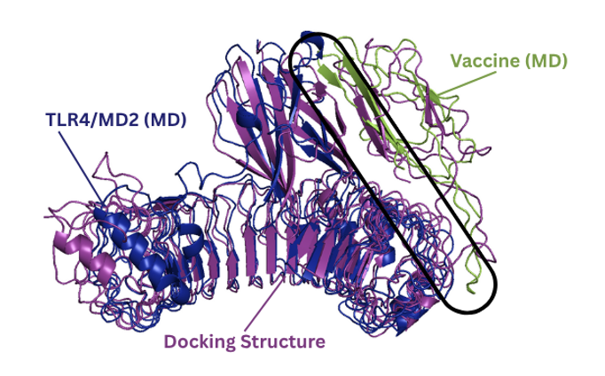

```python
show cartoon, docking
color purple, docking

show cartoon, md
color blue, md
```

*Figure: Overlay of the initial docked complex (TLR4/MD2 and the vaccine) and representative MD-refined structure, with labels for clarification.*

## RMSD Evaluation

PyMOL reports `RMSD` after alignment:

```python
rms_cur md, docking
```

Lower `RMSD` values indicate structural stability, while higher values suggest conformational rearrangement during simulation.

## Interpretation

- **Low RMSD (< 2–3 Å):**  
  Indicates structural stability and preservation of the docking pose.
- **Moderate RMSD (3–5 Å):**  
  Suggests minor conformational adjustments, often improving interface packing.
- **High RMSD (> 5 Å):**  
  Indicates significant structural rearrangement, potentially reflecting instability or alternative binding modes.

Structural deviations should be interpreted alongside `RMSD`, `RMSF`, and `hydrogen bonding` analyses to determine whether changes are *stabilizing* or *destabilizing*.

## Interface Visualization

Define vaccine and receptor components (manual renaming may be required depending on chain assignments):

```python
# Rename selections appropriately in PyMOL
# Example:
# rename complex → receptor
# rename chain(s) → vaccine
```

Highlight interface residues:

```python
select interface_sel, byres ((vaccine within 4 of receptor) or (receptor within 4 of vaccine))
create interface, interface_sel

show surface, interface

color blue, interface and (interface like receptor)
color green, interface and (interface like vaccine)
```

## Output

Representative comparison images can be generated in PyMOL:

```python
ray 3000,3000
png docking_vs_md.png
```

Multiple orientations are recommended to capture interface changes.

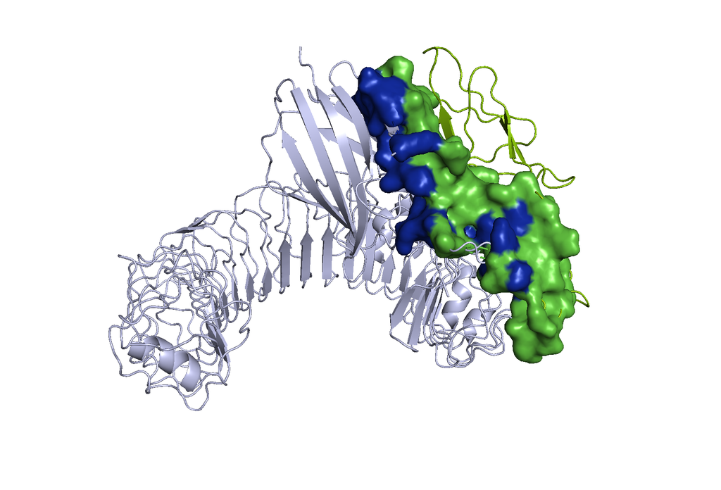

# Electrostatic Surface Representation

This section describes the workflow used to compute and visualize Electrostatic Surface Potentials for representative MD structures using `APBS` and `PyMOL`.

## Environment Setup

Create and activate a dedicated `Conda` environment:

```bash
conda create -n electrostatics_env python=3.10 -y
conda activate electrostatics_env
conda install -c conda-forge pdb2pqr apbs
```

## Structure Preparation

Convert the representative MD structure (`md_rep_structure.pdb`) to `PQR` format:

```bash
pdb2pqr30 --ff CHARMM md_rep_structure.pdb complex_md.pqr
```

## APBS Input File

Create an `APBS` input file (e.g., `complex_md.in`):

```bash
nano complex_md.in
```

Insert the following:

```
read
  mol pqr complex_md.pqr
end

elec
  mg-auto
  dime 161 161 161
  cglen 160.0 160.0 160.0
  fglen 140.0 140.0 140.0
  cgcent mol 1
  fgcent mol 1
  mol 1
  lpbe
  bcfl sdh
  ion charge 1 conc 0.15 radius 2.0
  ion charge -1 conc 0.15 radius 2.0
  pdie 2.0
  sdie 78.54
  srfm smol
  chgm spl2
  sdens 10.0
  srad 1.4
  swin 0.3
  temp 298.15
  calcenergy no
  calcforce no
  write
    pot dx complex_md
  end
end

quit
```

Save and exit.

## Run APBS

```bash
apbs complex_md.in
```

This generates an electrostatic potential map (`.dx` file).

## Visualization in PyMOL

Load the structure and electrostatic map:

*Note: It will again be necessary to separate receptor and vaccine chains/sequences, either manually or using CLI*

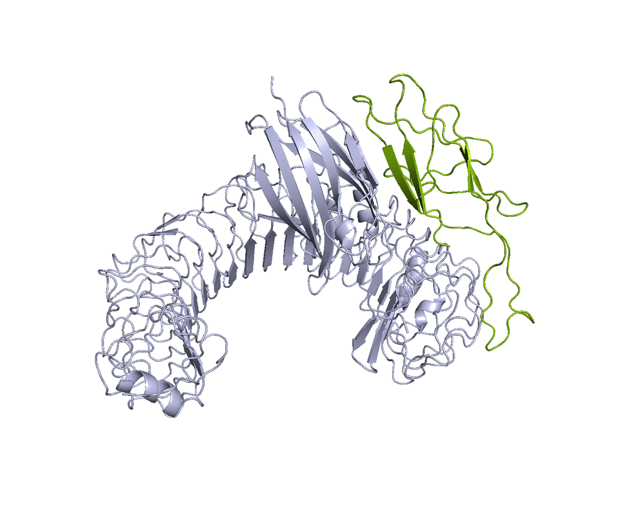

```python
load complex_md.pqr, complex
load complex_md.dx, complex_map

color splitpea, vaccine
color lightblue, receptor
```

Create an electrostatic color ramp:

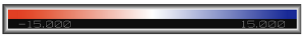

```python
ramp_new complex_pot, complex_map, [-15, 0, 15]
```

## Electrostatic Surface Rendering

### Vaccine Electrostatic Representation

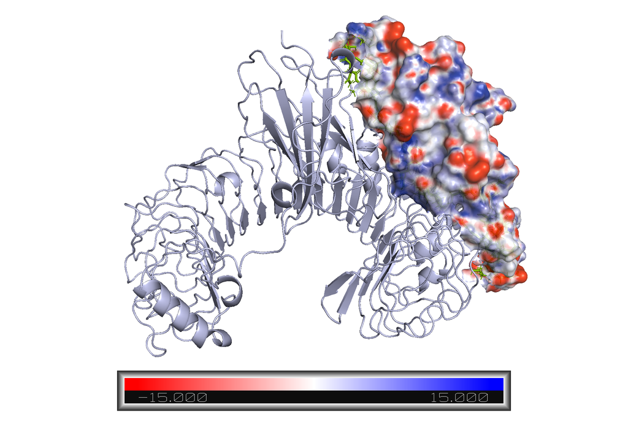

```python
set surface_color, complex_pot, vaccine
show surface, vaccine
set transparency, 0.15, vaccine
set surface_quality, 1
set two_sided_lighting, on
```

### Receptor Electrostatic Representation

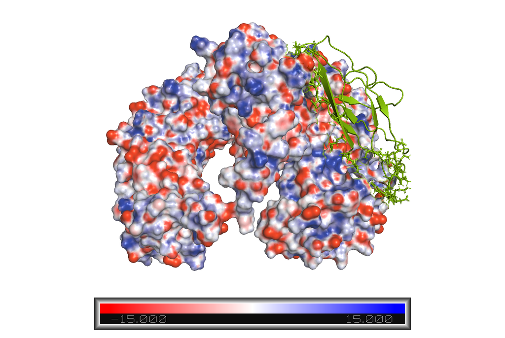

```python
hide surface, vaccine
show cartoon, vaccine
set transparency, 0, vaccine

set surface_color, complex_pot, receptor
show surface, receptor
set transparency, 0.15, receptor
set surface_quality, 1
set two_sided_lighting, on
```

# Notes

- `HPC` scripts are designed for `SLURM`-based clusters
- Group indices in `GROMACS` may vary depending on the system

## Conclusion

Presented here is a reproducible and modular workflow for the analysis and visualization of molecular dynamics simulations of vaccine–receptor complexes. Beginning with raw trajectory data, the pipeline integrates trajectory processing, quantitative stability metrics, representative structure extraction, and structure-based visualization into a unified framework.

System stability and conformational behavior are evaluated using complementary metrics, including **root mean square deviation** (`RMSD`), **root mean square fluctuation** (`RMSF`), and **radius of gyration** (`Rg`), alongside **hydrogen bonding analysis** (`hbond`) to characterize interaction persistence. Together, these measures provide a multidimensional assessment of structural integrity, flexibility, and intermolecular stability throughout the simulation.

Extraction of a representative structure via clustering enables downstream structural interpretation and facilitates direct comparison between initial docking models and `MD`-refined conformations. This comparison reveals interface-level adjustments and conformational refinement, offering insight into the stability and plausibility of predicted binding modes.

Electrostatic surface potential calculations, performed using **APBS** and visualized in **PyMOL**, further extend the analysis by mapping charge distributions and identifying potential *interaction hotspots* at the molecular interface.

Collectively, this workflow establishes a robust and extensible platform for the interpretation of `MD` simulations in the context of **structure-based vaccine design** and **protein–protein interaction analysis**.

## Reproducibility and Extensibility

All scripts, example datasets, and visualization workflows are provided within this repository. The pipeline is designed to be modular, enabling straightforward adaptation to alternative molecular systems generated using **GROMACS**.

## Future Directions

This framework can be extended to incorporate additional analyses, including:

- Binding free energy calculations (**MM/PBSA**, **MM/GBSA**)
- Principal component analysis (**PCA**) of conformational dynamics
- Residue-level interaction network and contact analysis
- Comparative evaluation across multiple complexes or simulation replicates

## Availability

The complete workflow, including documentation and interactive visualization, is available at:

https://vsgosnell.github.io/MD-Simulation-Analysis/